# Risk Factor Analysis

## Outcome Variable

**Outcome Variable:** haz

## Predictor Variables

**Intervention Variable:** meducyrs

**Adjustment Set:**

unadjusted

## Stratifying Variables

The analysis was stratified on these variable(s):

- agecat
- studyid
- country

## Data Summary

| agecat | studyid | country | meducyrs | n_cell | n |
| --- | --- | --- | --- | --- | --- |
| Birth | ki0047075b-MAL-ED | BANGLADESH | High | 75 | 207 |
| Birth | ki0047075b-MAL-ED | BANGLADESH | Low | 68 | 207 |
| Birth | ki0047075b-MAL-ED | BANGLADESH | Medium | 64 | 207 |
| Birth | ki0047075b-MAL-ED | BRAZIL | High | 65 | 190 |
| Birth | ki0047075b-MAL-ED | BRAZIL | Low | 52 | 190 |
| Birth | ki0047075b-MAL-ED | BRAZIL | Medium | 73 | 190 |
| Birth | ki0047075b-MAL-ED | INDIA | High | 51 | 183 |
| Birth | ki0047075b-MAL-ED | INDIA | Low | 61 | 183 |
| Birth | ki0047075b-MAL-ED | INDIA | Medium | 71 | 183 |
| Birth | ki0047075b-MAL-ED | NEPAL | High | 37 | 160 |
| Birth | ki0047075b-MAL-ED | NEPAL | Low | 68 | 160 |
| Birth | ki0047075b-MAL-ED | NEPAL | Medium | 55 | 160 |
| Birth | ki0047075b-MAL-ED | PERU | High | 87 | 286 |
| Birth | ki0047075b-MAL-ED | PERU | Low | 99 | 286 |
| Birth | ki0047075b-MAL-ED | PERU | Medium | 100 | 286 |
| Birth | ki0047075b-MAL-ED | SOUTH AFRICA | High | 72 | 262 |
| Birth | ki0047075b-MAL-ED | SOUTH AFRICA | Low | 133 | 262 |
| Birth | ki0047075b-MAL-ED | SOUTH AFRICA | Medium | 57 | 262 |
| Birth | ki0047075b-MAL-ED | TANZANIA, UNITED REPUBLIC OF | High | 4 | 107 |
| Birth | ki0047075b-MAL-ED | TANZANIA, UNITED REPUBLIC OF | Low | 35 | 107 |
| Birth | ki0047075b-MAL-ED | TANZANIA, UNITED REPUBLIC OF | Medium | 68 | 107 |
| Birth | ki1000108-CMC-V-BCS-2002 | INDIA | High | 50 | 90 |
| Birth | ki1000108-CMC-V-BCS-2002 | INDIA | Low | 15 | 90 |
| Birth | ki1000108-CMC-V-BCS-2002 | INDIA | Medium | 25 | 90 |
| Birth | ki1000108-IRC | INDIA | High | 113 | 388 |
| Birth | ki1000108-IRC | INDIA | Low | 142 | 388 |
| Birth | ki1000108-IRC | INDIA | Medium | 133 | 388 |
| Birth | ki1000109-EE | PAKISTAN | High | 0 | 2 |
| Birth | ki1000109-EE | PAKISTAN | Low | 2 | 2 |
| Birth | ki1000109-EE | PAKISTAN | Medium | 0 | 2 |

[output cut: 174 more lines]

The following strata were considered:

- agecat: 24 months, studyid: ki0047075b-MAL-ED, country: BANGLADESH
- agecat: 24 months, studyid: ki0047075b-MAL-ED, country: BRAZIL
- agecat: 24 months, studyid: ki0047075b-MAL-ED, country: INDIA
- agecat: 24 months, studyid: ki0047075b-MAL-ED, country: NEPAL
- agecat: 24 months, studyid: ki0047075b-MAL-ED, country: PERU
- agecat: 24 months, studyid: ki0047075b-MAL-ED, country: SOUTH AFRICA
- agecat: 24 months, studyid: ki0047075b-MAL-ED, country: TANZANIA, UNITED REPUBLIC OF
- agecat: 24 months, studyid: ki1000108-CMC-V-BCS-2002, country: INDIA
- agecat: 24 months, studyid: ki1000108-IRC, country: INDIA
- agecat: 24 months, studyid: ki1017093-NIH-Birth, country: BANGLADESH
- agecat: 24 months, studyid: ki1017093b-PROVIDE, country: BANGLADESH
- agecat: 24 months, studyid: ki1017093c-NIH-Crypto, country: BANGLADESH
- agecat: 24 months, studyid: ki1066203-TanzaniaChild2, country: TANZANIA, UNITED REPUBLIC OF
- agecat: 24 months, studyid: ki1113344-GMS-Nepal, country: NEPAL
- agecat: 24 months, studyid: ki1119695-PROBIT, country: BELARUS
- agecat: 24 months, studyid: ki1126311-ZVITAMBO, country: ZIMBABWE
- agecat: 24 months, studyid: ki1135781-COHORTS, country: GUATEMALA
- agecat: 24 months, studyid: ki1135781-COHORTS, country: INDIA
- agecat: 24 months, studyid: ki1135781-COHORTS, country: PHILIPPINES
- agecat: 24 months, studyid: ki1148112-LCNI-5, country: MALAWI
- agecat: 24 months, studyid: kiGH5241-JiVitA-3, country: BANGLADESH
- agecat: 24 months, studyid: kiGH5241-JiVitA-4, country: BANGLADESH
- agecat: 6 months, studyid: ki0047075b-MAL-ED, country: BANGLADESH
- agecat: 6 months, studyid: ki0047075b-MAL-ED, country: BRAZIL
- agecat: 6 months, studyid: ki0047075b-MAL-ED, country: INDIA
- agecat: 6 months, studyid: ki0047075b-MAL-ED, country: NEPAL
- agecat: 6 months, studyid: ki0047075b-MAL-ED, country: PERU
- agecat: 6 months, studyid: ki0047075b-MAL-ED, country: SOUTH AFRICA
- agecat: 6 months, studyid: ki0047075b-MAL-ED, country: TANZANIA, UNITED REPUBLIC OF
- agecat: 6 months, studyid: ki1000108-CMC-V-BCS-2002, country: INDIA
- agecat: 6 months, studyid: ki1000108-IRC, country: INDIA
- agecat: 6 months, studyid: ki1000109-EE, country: PAKISTAN
- agecat: 6 months, studyid: ki1000304b-SAS-CompFeed, country: INDIA
- agecat: 6 months, studyid: ki1000304b-SAS-FoodSuppl, country: INDIA
- agecat: 6 months, studyid: ki1017093-NIH-Birth, country: BANGLADESH
- agecat: 6 months, studyid: ki1017093b-PROVIDE, country: BANGLADESH
- agecat: 6 months, studyid: ki1017093c-NIH-Crypto, country: BANGLADESH
- agecat: 6 months, studyid: ki1066203-TanzaniaChild2, country: TANZANIA, UNITED REPUBLIC OF
- agecat: 6 months, studyid: ki1112895-Guatemala BSC, country: GUATEMALA
- agecat: 6 months, studyid: ki1113344-GMS-Nepal, country: NEPAL
- agecat: 6 months, studyid: ki1119695-PROBIT, country: BELARUS
- agecat: 6 months, studyid: ki1126311-ZVITAMBO, country: ZIMBABWE
- agecat: 6 months, studyid: ki1135781-COHORTS, country: GUATEMALA
- agecat: 6 months, studyid: ki1135781-COHORTS, country: INDIA
- agecat: 6 months, studyid: ki1135781-COHORTS, country: PHILIPPINES
- agecat: 6 months, studyid: ki1148112-LCNI-5, country: MALAWI
- agecat: 6 months, studyid: kiGH5241-JiVitA-3, country: BANGLADESH
- agecat: 6 months, studyid: kiGH5241-JiVitA-4, country: BANGLADESH
- agecat: Birth, studyid: ki0047075b-MAL-ED, country: BANGLADESH
- agecat: Birth, studyid: ki0047075b-MAL-ED, country: BRAZIL
- agecat: Birth, studyid: ki0047075b-MAL-ED, country: INDIA
- agecat: Birth, studyid: ki0047075b-MAL-ED, country: NEPAL
- agecat: Birth, studyid: ki0047075b-MAL-ED, country: PERU
- agecat: Birth, studyid: ki0047075b-MAL-ED, country: SOUTH AFRICA
- agecat: Birth, studyid: ki0047075b-MAL-ED, country: TANZANIA, UNITED REPUBLIC OF
- agecat: Birth, studyid: ki1000108-CMC-V-BCS-2002, country: INDIA
- agecat: Birth, studyid: ki1000108-IRC, country: INDIA
- agecat: Birth, studyid: ki1000109-EE, country: PAKISTAN
- agecat: Birth, studyid: ki1000304b-SAS-CompFeed, country: INDIA
- agecat: Birth, studyid: ki1017093-NIH-Birth, country: BANGLADESH
- agecat: Birth, studyid: ki1017093c-NIH-Crypto, country: BANGLADESH
- agecat: Birth, studyid: ki1119695-PROBIT, country: BELARUS
- agecat: Birth, studyid: ki1126311-ZVITAMBO, country: ZIMBABWE
- agecat: Birth, studyid: ki1135781-COHORTS, country: GUATEMALA
- agecat: Birth, studyid: ki1135781-COHORTS, country: INDIA
- agecat: Birth, studyid: ki1135781-COHORTS, country: PHILIPPINES
- agecat: Birth, studyid: kiGH5241-JiVitA-3, country: BANGLADESH
- agecat: Birth, studyid: kiGH5241-JiVitA-4, country: BANGLADESH

### Dropped Strata

Some strata were dropped due to rare outcomes:

- agecat: Birth, studyid: ki0047075b-MAL-ED, country: TANZANIA, UNITED REPUBLIC OF
- agecat: Birth, studyid: ki1000109-EE, country: PAKISTAN
- agecat: Birth, studyid: ki1017093-NIH-Birth, country: BANGLADESH
- agecat: 24 months, studyid: ki1066203-TanzaniaChild2, country: TANZANIA, UNITED REPUBLIC OF

## Methods Detail

We’re interested in the causal parameters $E[Y_a]$ for all values of $a \in \mathcal{A}$. These parameters represent the mean outcome if, possibly contrary to fact, we intervened to set all units to have $A=a$. Under the randomization and positivity assumptions, these are identified by the statistical parameters $\psi_a=E_W[E_{Y|A,W}(Y|A=a,W)]$. In addition, we’re interested in the mean of $Y$, $E[Y]$ under no intervention (the observed mean). We will estimate these parameters by using SuperLearner to fit the relevant likelihood factors – $E_{Y|A,W}(Y|A=a,W)$ and $p(A=a|W)$, and then updating our likelihood fit using a joint TMLE.

For unadjusted analyses ($W=\{\}$), initial likelihoods were estimated using Lrnr_glm to estimate the simple $E(Y|A)$ and Lrnr_mean to estimate $p(A)$. For adjusted analyses, a small library containing Lrnr_glmnet, Lrnr_xgboost, and Lrnr_mean was used.

Having estimated these parameters, we will then use the delta method to estimate relative risks and attributable risks relative to a prespecified baseline level of $A$.

# Results Detail

## Results Plots

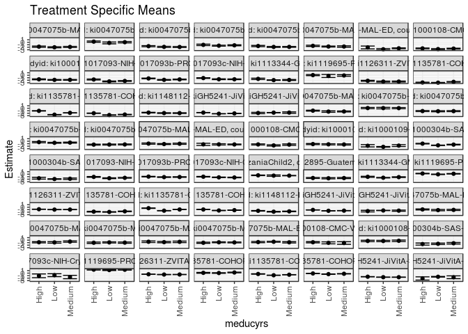

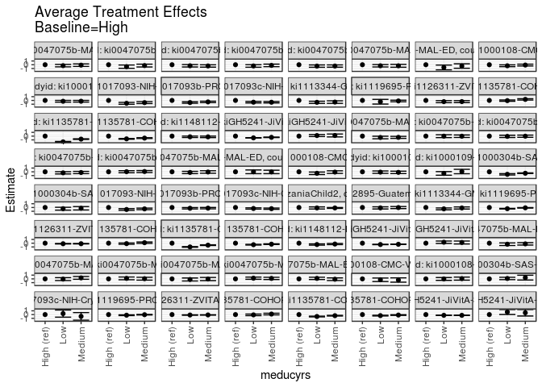

[figure not shown]

## Results Table

### Parameter: TSM

| agecat | studyid | country | intervention_level | baseline_level | estimate | ci_lower | ci_upper |
| --- | --- | --- | --- | --- | --- | --- | --- |
| Birth | ki0047075b-MAL-ED | BANGLADESH | High | NA | -0.9116000 | -1.1276931 | -0.6955069 |
| Birth | ki0047075b-MAL-ED | BANGLADESH | Low | NA | -1.1833824 | -1.4497071 | -0.9170576 |
| Birth | ki0047075b-MAL-ED | BANGLADESH | Medium | NA | -1.0910938 | -1.3200533 | -0.8621342 |
| Birth | ki0047075b-MAL-ED | BRAZIL | High | NA | -0.8476923 | -1.0935994 | -0.6017852 |
| Birth | ki0047075b-MAL-ED | BRAZIL | Low | NA | -0.9042308 | -1.2006734 | -0.6077881 |
| Birth | ki0047075b-MAL-ED | BRAZIL | Medium | NA | -0.5845205 | -0.8550128 | -0.3140283 |
| Birth | ki0047075b-MAL-ED | INDIA | High | NA | -1.0364706 | -1.3227758 | -0.7501653 |
| Birth | ki0047075b-MAL-ED | INDIA | Low | NA | -0.9036066 | -1.1311304 | -0.6760827 |
| Birth | ki0047075b-MAL-ED | INDIA | Medium | NA | -0.9874648 | -1.2341383 | -0.7407913 |
| Birth | ki0047075b-MAL-ED | NEPAL | High | NA | -0.6359459 | -0.9435608 | -0.3283311 |
| Birth | ki0047075b-MAL-ED | NEPAL | Low | NA | -0.7982353 | -1.0527207 | -0.5437499 |
| Birth | ki0047075b-MAL-ED | NEPAL | Medium | NA | -0.6761818 | -0.9681368 | -0.3842268 |
| Birth | ki0047075b-MAL-ED | PERU | High | NA | -1.0439080 | -1.2791777 | -0.8086384 |
| Birth | ki0047075b-MAL-ED | PERU | Low | NA | -0.8590909 | -1.0360586 | -0.6821233 |
| Birth | ki0047075b-MAL-ED | PERU | Medium | NA | -0.9145000 | -1.0973620 | -0.7316380 |
| Birth | ki0047075b-MAL-ED | SOUTH AFRICA | High | NA | -0.7750000 | -1.0143837 | -0.5356163 |
| Birth | ki0047075b-MAL-ED | SOUTH AFRICA | Low | NA | -0.6406767 | -0.8261841 | -0.4551693 |
| Birth | ki0047075b-MAL-ED | SOUTH AFRICA | Medium | NA | -0.8659649 | -1.1241936 | -0.6077363 |
| Birth | ki1000108-CMC-V-BCS-2002 | INDIA | High | NA | -0.8422000 | -1.0839302 | -0.6004698 |
| Birth | ki1000108-CMC-V-BCS-2002 | INDIA | Low | NA | -1.0800000 | -1.4787006 | -0.6812994 |
| Birth | ki1000108-CMC-V-BCS-2002 | INDIA | Medium | NA | -1.1432000 | -1.6560634 | -0.6303366 |
| Birth | ki1000108-IRC | INDIA | High | NA | -0.3259292 | -0.6063276 | -0.0455308 |
| Birth | ki1000108-IRC | INDIA | Low | NA | -0.3416901 | -0.5985971 | -0.0847832 |
| Birth | ki1000108-IRC | INDIA | Medium | NA | -0.2569173 | -0.5532520 | 0.0394175 |
| Birth | ki1000304b-SAS-CompFeed | INDIA | High | NA | -1.5693548 | -1.9853452 | -1.1533645 |
| Birth | ki1000304b-SAS-CompFeed | INDIA | Low | NA | -1.4584884 | -1.7306570 | -1.1863198 |
| Birth | ki1000304b-SAS-CompFeed | INDIA | Medium | NA | -1.2388571 | -1.5445794 | -0.9331349 |
| Birth | ki1017093c-NIH-Crypto | BANGLADESH | High | NA | -1.0857143 | -1.8365987 | -0.3348299 |
| Birth | ki1017093c-NIH-Crypto | BANGLADESH | Low | NA | -0.8208333 | -1.4017622 | -0.2399044 |
| Birth | ki1017093c-NIH-Crypto | BANGLADESH | Medium | NA | -1.5650000 | -2.2384504 | -0.8915496 |

[output cut: 162 more lines]

### Parameter: E(Y)

| agecat | studyid | country | intervention_level | baseline_level | estimate | ci_lower | ci_upper |
| --- | --- | --- | --- | --- | --- | --- | --- |
| Birth | ki0047075b-MAL-ED | BANGLADESH | NA | NA | -1.0563768 | -1.1943724 | -0.9183812 |
| Birth | ki0047075b-MAL-ED | BRAZIL | NA | NA | -0.7620526 | -0.9197540 | -0.6043512 |
| Birth | ki0047075b-MAL-ED | INDIA | NA | NA | -0.9731694 | -1.1192409 | -0.8270979 |
| Birth | ki0047075b-MAL-ED | NEPAL | NA | NA | -0.7187500 | -0.8829096 | -0.5545904 |
| Birth | ki0047075b-MAL-ED | PERU | NA | NA | -0.9346853 | -1.0488784 | -0.8204922 |
| Birth | ki0047075b-MAL-ED | SOUTH AFRICA | NA | NA | -0.7266031 | -0.8549719 | -0.5982342 |
| Birth | ki1000108-CMC-V-BCS-2002 | INDIA | NA | NA | -0.9654444 | -1.1742112 | -0.7566777 |
| Birth | ki1000108-IRC | INDIA | NA | NA | -0.3080412 | -0.4687931 | -0.1472894 |
| Birth | ki1000304b-SAS-CompFeed | INDIA | NA | NA | -1.3946524 | -1.5833612 | -1.2059436 |
| Birth | ki1017093c-NIH-Crypto | BANGLADESH | NA | NA | -1.1100000 | -1.5086894 | -0.7113106 |
| Birth | ki1119695-PROBIT | BELARUS | NA | NA | 1.3254775 | 1.1669293 | 1.4840258 |
| Birth | ki1126311-ZVITAMBO | ZIMBABWE | NA | NA | -0.5013671 | -0.5219633 | -0.4807709 |
| Birth | ki1135781-COHORTS | GUATEMALA | NA | NA | 0.1288717 | 0.0445170 | 0.2132265 |
| Birth | ki1135781-COHORTS | INDIA | NA | NA | -0.6688842 | -0.7003528 | -0.6374156 |
| Birth | ki1135781-COHORTS | PHILIPPINES | NA | NA | -0.2490492 | -0.2880580 | -0.2100404 |
| Birth | kiGH5241-JiVitA-3 | BANGLADESH | NA | NA | -1.5750447 | -1.5948316 | -1.5552578 |
| Birth | kiGH5241-JiVitA-4 | BANGLADESH | NA | NA | -1.4750409 | -1.5891321 | -1.3609496 |
| 6 months | ki0047075b-MAL-ED | BANGLADESH | NA | NA | -1.1935544 | -1.3251572 | -1.0619516 |
| 6 months | ki0047075b-MAL-ED | BRAZIL | NA | NA | 0.0529327 | -0.0917526 | 0.1976180 |
| 6 months | ki0047075b-MAL-ED | INDIA | NA | NA | -1.1704327 | -1.2921639 | -1.0487015 |
| 6 months | ki0047075b-MAL-ED | NEPAL | NA | NA | -0.5483560 | -0.6619002 | -0.4348118 |
| 6 months | ki0047075b-MAL-ED | PERU | NA | NA | -1.3312377 | -1.4396065 | -1.2228689 |
| 6 months | ki0047075b-MAL-ED | SOUTH AFRICA | NA | NA | -1.0633760 | -1.1911088 | -0.9356432 |
| 6 months | ki0047075b-MAL-ED | TANZANIA, UNITED REPUBLIC OF | NA | NA | -1.2832512 | -1.4141440 | -1.1523584 |
| 6 months | ki1000108-CMC-V-BCS-2002 | INDIA | NA | NA | -1.4234508 | -1.5645974 | -1.2823042 |
| 6 months | ki1000108-IRC | INDIA | NA | NA | -1.2344062 | -1.3658524 | -1.1029600 |
| 6 months | ki1000109-EE | PAKISTAN | NA | NA | -2.1956098 | -2.3191627 | -2.0720568 |
| 6 months | ki1000304b-SAS-CompFeed | INDIA | NA | NA | -1.4018563 | -1.4810585 | -1.3226541 |
| 6 months | ki1000304b-SAS-FoodSuppl | INDIA | NA | NA | -1.8986842 | -2.0118892 | -1.7854792 |
| 6 months | ki1017093-NIH-Birth | BANGLADESH | NA | NA | -1.4073821 | -1.4960598 | -1.3187043 |
| 6 months | ki1017093b-PROVIDE | BANGLADESH | NA | NA | -1.0871041 | -1.1635539 | -1.0106543 |
| 6 months | ki1017093c-NIH-Crypto | BANGLADESH | NA | NA | -1.1986783 | -1.2700937 | -1.1272630 |
| 6 months | ki1066203-TanzaniaChild2 | TANZANIA, UNITED REPUBLIC OF | NA | NA | -0.5440108 | -0.5930025 | -0.4950192 |
| 6 months | ki1112895-Guatemala BSC | GUATEMALA | NA | NA | -1.5624368 | -1.6783540 | -1.4465196 |
| 6 months | ki1113344-GMS-Nepal | NEPAL | NA | NA | -1.3322083 | -1.4107364 | -1.2536803 |
| 6 months | ki1119695-PROBIT | BELARUS | NA | NA | 0.1069986 | 0.0122286 | 0.2017686 |
| 6 months | ki1126311-ZVITAMBO | ZIMBABWE | NA | NA | -0.8916958 | -0.9176814 | -0.8657103 |
| 6 months | ki1135781-COHORTS | GUATEMALA | NA | NA | -1.8103361 | -1.8786415 | -1.7420307 |
| 6 months | ki1135781-COHORTS | INDIA | NA | NA | -1.0183078 | -1.0495042 | -0.9871113 |
| 6 months | ki1135781-COHORTS | PHILIPPINES | NA | NA | -1.1405724 | -1.1824954 | -1.0986493 |
| 6 months | ki1148112-LCNI-5 | MALAWI | NA | NA | -1.6431488 | -1.7125598 | -1.5737379 |
| 6 months | kiGH5241-JiVitA-3 | BANGLADESH | NA | NA | -1.3131339 | -1.3362896 | -1.2899781 |
| 6 months | kiGH5241-JiVitA-4 | BANGLADESH | NA | NA | -1.3385142 | -1.3948471 | -1.2821814 |
| 24 months | ki0047075b-MAL-ED | BANGLADESH | NA | NA | -1.8744152 | -2.0076626 | -1.7411678 |
| 24 months | ki0047075b-MAL-ED | BRAZIL | NA | NA | 0.0434524 | -0.1247334 | 0.2116382 |
| 24 months | ki0047075b-MAL-ED | INDIA | NA | NA | -1.7845980 | -1.9142624 | -1.6549336 |
| 24 months | ki0047075b-MAL-ED | NEPAL | NA | NA | -1.2366901 | -1.3594733 | -1.1139070 |
| 24 months | ki0047075b-MAL-ED | PERU | NA | NA | -1.7521250 | -1.8731109 | -1.6311391 |
| 24 months | ki0047075b-MAL-ED | SOUTH AFRICA | NA | NA | -1.6228361 | -1.7581177 | -1.4875546 |
| 24 months | ki0047075b-MAL-ED | TANZANIA, UNITED REPUBLIC OF | NA | NA | -2.5264286 | -2.6690955 | -2.3837616 |
| 24 months | ki1000108-CMC-V-BCS-2002 | INDIA | NA | NA | -2.5593683 | -2.6601027 | -2.4586339 |
| 24 months | ki1000108-IRC | INDIA | NA | NA | -1.7824776 | -1.8765600 | -1.6883952 |
| 24 months | ki1017093-NIH-Birth | BANGLADESH | NA | NA | -2.1807945 | -2.2835902 | -2.0779987 |
| 24 months | ki1017093b-PROVIDE | BANGLADESH | NA | NA | -1.5861179 | -1.6693668 | -1.5028689 |
| 24 months | ki1017093c-NIH-Crypto | BANGLADESH | NA | NA | -1.4295331 | -1.5127726 | -1.3462935 |
| 24 months | ki1113344-GMS-Nepal | NEPAL | NA | NA | -1.8849429 | -1.9699639 | -1.7999219 |
| 24 months | ki1119695-PROBIT | BELARUS | NA | NA | -0.1314048 | -0.4282725 | 0.1654630 |
| 24 months | ki1126311-ZVITAMBO | ZIMBABWE | NA | NA | -2.3994530 | -2.5144490 | -2.2844569 |
| 24 months | ki1135781-COHORTS | GUATEMALA | NA | NA | -2.8575660 | -2.9223159 | -2.7928162 |
| 24 months | ki1135781-COHORTS | INDIA | NA | NA | -1.9615163 | -1.9983763 | -1.9246563 |
| 24 months | ki1135781-COHORTS | PHILIPPINES | NA | NA | -2.3898650 | -2.4346888 | -2.3450412 |
| 24 months | ki1148112-LCNI-5 | MALAWI | NA | NA | -1.8686713 | -1.9502344 | -1.7871083 |
| 24 months | kiGH5241-JiVitA-3 | BANGLADESH | NA | NA | -2.0124336 | -2.0401325 | -1.9847347 |
| 24 months | kiGH5241-JiVitA-4 | BANGLADESH | NA | NA | -1.7686889 | -1.8213457 | -1.7160321 |

### Parameter: ATE

| agecat | studyid | country | intervention_level | baseline_level | estimate | ci_lower | ci_upper |
| --- | --- | --- | --- | --- | --- | --- | --- |
| Birth | ki0047075b-MAL-ED | BANGLADESH | High | High | 0.0000000 | 0.0000000 | 0.0000000 |
| Birth | ki0047075b-MAL-ED | BANGLADESH | Low | High | -0.2717824 | -0.6147476 | 0.0711829 |
| Birth | ki0047075b-MAL-ED | BANGLADESH | Medium | High | -0.1794938 | -0.4943250 | 0.1353375 |
| Birth | ki0047075b-MAL-ED | BRAZIL | High | High | 0.0000000 | 0.0000000 | 0.0000000 |
| Birth | ki0047075b-MAL-ED | BRAZIL | Low | High | -0.0565385 | -0.4416989 | 0.3286219 |
| Birth | ki0047075b-MAL-ED | BRAZIL | Medium | High | 0.2631718 | -0.1023913 | 0.6287348 |
| Birth | ki0047075b-MAL-ED | INDIA | High | High | 0.0000000 | 0.0000000 | 0.0000000 |
| Birth | ki0047075b-MAL-ED | INDIA | Low | High | 0.1328640 | -0.2328378 | 0.4985658 |
| Birth | ki0047075b-MAL-ED | INDIA | Medium | High | 0.0490058 | -0.3289076 | 0.4269192 |
| Birth | ki0047075b-MAL-ED | NEPAL | High | High | 0.0000000 | 0.0000000 | 0.0000000 |
| Birth | ki0047075b-MAL-ED | NEPAL | Low | High | -0.1622893 | -0.5615257 | 0.2369470 |
| Birth | ki0047075b-MAL-ED | NEPAL | Medium | High | -0.0402359 | -0.4643404 | 0.3838686 |
| Birth | ki0047075b-MAL-ED | PERU | High | High | 0.0000000 | 0.0000000 | 0.0000000 |
| Birth | ki0047075b-MAL-ED | PERU | Low | High | 0.1848171 | -0.1095795 | 0.4792138 |
| Birth | ki0047075b-MAL-ED | PERU | Medium | High | 0.1294080 | -0.1685691 | 0.4273852 |
| Birth | ki0047075b-MAL-ED | SOUTH AFRICA | High | High | 0.0000000 | 0.0000000 | 0.0000000 |
| Birth | ki0047075b-MAL-ED | SOUTH AFRICA | Low | High | 0.1343233 | -0.1685257 | 0.4371724 |
| Birth | ki0047075b-MAL-ED | SOUTH AFRICA | Medium | High | -0.0909649 | -0.4430822 | 0.2611524 |
| Birth | ki1000108-CMC-V-BCS-2002 | INDIA | High | High | 0.0000000 | 0.0000000 | 0.0000000 |
| Birth | ki1000108-CMC-V-BCS-2002 | INDIA | Low | High | -0.2378000 | -0.7040571 | 0.2284571 |
| Birth | ki1000108-CMC-V-BCS-2002 | INDIA | Medium | High | -0.3010000 | -0.8679766 | 0.2659766 |
| Birth | ki1000108-IRC | INDIA | High | High | 0.0000000 | 0.0000000 | 0.0000000 |
| Birth | ki1000108-IRC | INDIA | Low | High | -0.0157609 | -0.3960561 | 0.3645342 |
| Birth | ki1000108-IRC | INDIA | Medium | High | 0.0690119 | -0.3389557 | 0.4769795 |
| Birth | ki1000304b-SAS-CompFeed | INDIA | High | High | 0.0000000 | 0.0000000 | 0.0000000 |
| Birth | ki1000304b-SAS-CompFeed | INDIA | Low | High | 0.1108665 | -0.2036991 | 0.4254320 |
| Birth | ki1000304b-SAS-CompFeed | INDIA | Medium | High | 0.3304977 | -0.3046797 | 0.9656751 |
| Birth | ki1017093c-NIH-Crypto | BANGLADESH | High | High | 0.0000000 | 0.0000000 | 0.0000000 |
| Birth | ki1017093c-NIH-Crypto | BANGLADESH | Low | High | 0.2648810 | -0.6844903 | 1.2142522 |
| Birth | ki1017093c-NIH-Crypto | BANGLADESH | Medium | High | -0.4792857 | -1.4879298 | 0.5293583 |

[output cut: 162 more lines]

### Parameter: PAR

| agecat | studyid | country | intervention_level | baseline_level | estimate | ci_lower | ci_upper |
| --- | --- | --- | --- | --- | --- | --- | --- |
| Birth | ki0047075b-MAL-ED | BANGLADESH | High | NA | -0.1447768 | -0.3233858 | 0.0338322 |
| Birth | ki0047075b-MAL-ED | BRAZIL | High | NA | 0.0856397 | -0.1240401 | 0.2953195 |
| Birth | ki0047075b-MAL-ED | INDIA | High | NA | 0.0633012 | -0.1767384 | 0.3033407 |
| Birth | ki0047075b-MAL-ED | NEPAL | High | NA | -0.0828041 | -0.3617491 | 0.1961410 |
| Birth | ki0047075b-MAL-ED | PERU | High | NA | 0.1092227 | -0.0771004 | 0.2955459 |
| Birth | ki0047075b-MAL-ED | SOUTH AFRICA | High | NA | 0.0483969 | -0.1572422 | 0.2540361 |
| Birth | ki1000108-CMC-V-BCS-2002 | INDIA | High | NA | -0.1232444 | -0.3158345 | 0.0693456 |
| Birth | ki1000108-IRC | INDIA | High | NA | 0.0178880 | -0.2243276 | 0.2601036 |
| Birth | ki1000304b-SAS-CompFeed | INDIA | High | NA | 0.1747024 | -0.1770884 | 0.5264933 |
| Birth | ki1017093c-NIH-Crypto | BANGLADESH | High | NA | -0.0242857 | -0.6803540 | 0.6317826 |
| Birth | ki1119695-PROBIT | BELARUS | High | NA | -0.0750118 | -0.1450632 | -0.0049604 |
| Birth | ki1126311-ZVITAMBO | ZIMBABWE | High | NA | -0.0487252 | -0.0676309 | -0.0298195 |
| Birth | ki1135781-COHORTS | GUATEMALA | High | NA | 0.0086470 | -0.1431013 | 0.1603954 |
| Birth | ki1135781-COHORTS | INDIA | High | NA | -0.3276158 | -0.4063714 | -0.2488602 |
| Birth | ki1135781-COHORTS | PHILIPPINES | High | NA | -0.1213246 | -0.1704250 | -0.0722243 |
| Birth | kiGH5241-JiVitA-3 | BANGLADESH | High | NA | -0.1411019 | -0.1685562 | -0.1136477 |
| Birth | kiGH5241-JiVitA-4 | BANGLADESH | High | NA | 0.6649591 | 0.0228143 | 1.3071039 |
| 6 months | ki0047075b-MAL-ED | BANGLADESH | High | NA | -0.2179152 | -0.3805710 | -0.0552593 |
| 6 months | ki0047075b-MAL-ED | BRAZIL | High | NA | -0.0138513 | -0.2112183 | 0.1835156 |
| 6 months | ki0047075b-MAL-ED | INDIA | High | NA | -0.0320994 | -0.2161405 | 0.1519418 |
| 6 months | ki0047075b-MAL-ED | NEPAL | High | NA | -0.1801799 | -0.3834116 | 0.0230518 |
| 6 months | ki0047075b-MAL-ED | PERU | High | NA | 0.0342149 | -0.1285442 | 0.1969741 |
| 6 months | ki0047075b-MAL-ED | SOUTH AFRICA | High | NA | -0.0999593 | -0.3037649 | 0.1038463 |
| 6 months | ki0047075b-MAL-ED | TANZANIA, UNITED REPUBLIC OF | High | NA | -0.0275105 | -0.4560406 | 0.4010196 |
| 6 months | ki1000108-CMC-V-BCS-2002 | INDIA | High | NA | -0.1355633 | -0.2993206 | 0.0281940 |
| 6 months | ki1000108-IRC | INDIA | High | NA | -0.0853683 | -0.2764190 | 0.1056824 |
| 6 months | ki1000109-EE | PAKISTAN | High | NA | -0.3676098 | -0.8230472 | 0.0878276 |
| 6 months | ki1000304b-SAS-CompFeed | INDIA | High | NA | -0.4274253 | -0.5207349 | -0.3341156 |
| 6 months | ki1000304b-SAS-FoodSuppl | INDIA | High | NA | -0.2786842 | -0.6185159 | 0.0611474 |
| 6 months | ki1017093-NIH-Birth | BANGLADESH | High | NA | -0.3203928 | -0.4559404 | -0.1848452 |
| 6 months | ki1017093b-PROVIDE | BANGLADESH | High | NA | -0.1224899 | -0.2249147 | -0.0200652 |
| 6 months | ki1017093c-NIH-Crypto | BANGLADESH | High | NA | -0.1910533 | -0.2907232 | -0.0913834 |
| 6 months | ki1066203-TanzaniaChild2 | TANZANIA, UNITED REPUBLIC OF | High | NA | -0.0890661 | -0.1766419 | -0.0014904 |
| 6 months | ki1112895-Guatemala BSC | GUATEMALA | High | NA | -0.0350864 | -0.1696804 | 0.0995076 |
| 6 months | ki1113344-GMS-Nepal | NEPAL | High | NA | -0.2795964 | -0.4917559 | -0.0674369 |
| 6 months | ki1119695-PROBIT | BELARUS | High | NA | -0.1545558 | -0.2136342 | -0.0954773 |
| 6 months | ki1126311-ZVITAMBO | ZIMBABWE | High | NA | -0.0669446 | -0.0908901 | -0.0429990 |
| 6 months | ki1135781-COHORTS | GUATEMALA | High | NA | -0.0139037 | -0.1481526 | 0.1203452 |
| 6 months | ki1135781-COHORTS | INDIA | High | NA | -0.6085388 | -0.6829736 | -0.5341039 |
| 6 months | ki1135781-COHORTS | PHILIPPINES | High | NA | -0.2071010 | -0.2602500 | -0.1539520 |
| 6 months | ki1148112-LCNI-5 | MALAWI | High | NA | -0.1841220 | -0.2745399 | -0.0937041 |
| 6 months | kiGH5241-JiVitA-3 | BANGLADESH | High | NA | -0.2091487 | -0.2336782 | -0.1846193 |
| 6 months | kiGH5241-JiVitA-4 | BANGLADESH | High | NA | 0.2404563 | -0.0678225 | 0.5487352 |
| 24 months | ki0047075b-MAL-ED | BANGLADESH | High | NA | -0.1148840 | -0.2966448 | 0.0668769 |
| 24 months | ki0047075b-MAL-ED | BRAZIL | High | NA | -0.2123541 | -0.4254657 | 0.0007575 |
| 24 months | ki0047075b-MAL-ED | INDIA | High | NA | -0.2200525 | -0.4196150 | -0.0204901 |
| 24 months | ki0047075b-MAL-ED | NEPAL | High | NA | -0.1995026 | -0.4392726 | 0.0402673 |
| 24 months | ki0047075b-MAL-ED | PERU | High | NA | -0.2525487 | -0.4513082 | -0.0537892 |
| 24 months | ki0047075b-MAL-ED | SOUTH AFRICA | High | NA | -0.2004481 | -0.4130713 | 0.0121752 |
| 24 months | ki0047075b-MAL-ED | TANZANIA, UNITED REPUBLIC OF | High | NA | -0.4464286 | -1.0084682 | 0.1156110 |
| 24 months | ki1000108-CMC-V-BCS-2002 | INDIA | High | NA | -0.1046953 | -0.2238093 | 0.0144187 |
| 24 months | ki1000108-IRC | INDIA | High | NA | -0.1540502 | -0.2984514 | -0.0096489 |
| 24 months | ki1017093-NIH-Birth | BANGLADESH | High | NA | -0.4720894 | -0.6300166 | -0.3141621 |
| 24 months | ki1017093b-PROVIDE | BANGLADESH | High | NA | -0.3093517 | -0.4209005 | -0.1978028 |
| 24 months | ki1017093c-NIH-Crypto | BANGLADESH | High | NA | -0.3014179 | -0.4080223 | -0.1948135 |
| 24 months | ki1113344-GMS-Nepal | NEPAL | High | NA | -0.4333912 | -0.6811147 | -0.1856676 |
| 24 months | ki1119695-PROBIT | BELARUS | High | NA | -0.1903531 | -0.4275472 | 0.0468410 |
| 24 months | ki1126311-ZVITAMBO | ZIMBABWE | High | NA | -0.1755017 | -0.3051053 | -0.0458982 |
| 24 months | ki1135781-COHORTS | GUATEMALA | High | NA | 0.0611899 | -0.0702383 | 0.1926182 |
| 24 months | ki1135781-COHORTS | INDIA | High | NA | -0.9046084 | -0.9823201 | -0.8268967 |
| 24 months | ki1135781-COHORTS | PHILIPPINES | High | NA | -0.3928410 | -0.4505750 | -0.3351069 |
| 24 months | ki1148112-LCNI-5 | MALAWI | High | NA | -0.1176713 | -0.2185535 | -0.0167891 |
| 24 months | kiGH5241-JiVitA-3 | BANGLADESH | High | NA | -0.2630861 | -0.2961289 | -0.2300433 |
| 24 months | kiGH5241-JiVitA-4 | BANGLADESH | High | NA | 0.1445505 | -0.1147101 | 0.4038111 |